# Estimating London's EU referendum result with Multilevel Regression and Poststratification

In the previous notebook we encountered a predominance of missing data for Ward Level EU Referendum Electoral Results. Given our initial notebook SciKite Leran exploration of a correlation between the 2011 Census Data and EU Refendum Response, we extend this process with Multilevel Regression and Poststratification and PYMC3, as detailed by Austin Roachford's Python exploration of jonathan Kastellac MRP R Primer - to estiamte values for the Missing Ward Data. We then compare our restuls with Constiteuncy level EU Ref Result data obtained from a subsequent study by Chris Hannretty. We use Disagregation of the EU Ref Result data to highlight the missing data.

Links to both the Notebooks and Research can be found below.

### Libraries

```python
%matplotlib inline
#%config InlineBackend.figure_format = 'retina'
```

```python
import matplotlib as mpl
from matplotlib import pyplot as plt
from matplotlib.colors import Normalize, rgb2hex
from matplotlib.patches import Polygon
from matplotlib.ticker import FuncFormatter
#from mpl_toolkits.basemap import Basemap
```

```python
import pandas as pd
import numpy as np
import os
import os
import scipy as sp
```

```python
from theano import shared
import pymc3 as pm
```

```python
import seaborn as sns
```

### References:

https://gist.github.com/AustinRochford/bfc20cb3262169b41b730bd9faf74477

https://scholar.princeton.edu/jkastellec/publications/race-context-and-judging-courts-appeals-race-based-panel-effects-death-0

We will refer to each unique combination of state and demographic characteristics as a cell. Let $n_i$ denote the number of respondents in cell $i$, $y_i$ the number of those respondents that supported Remaining in the EU Referendum and $p_i$ the probability that a member of the general population of cell $i$ supports the Remain Camp. We build a Bayesian multilevel logistic regression model of opinion as follows.

Here each subscript indexed by $i$ is the categorical level of that characteristic for respondents in cell $i$. The prior for the intercept is $\beta_0 \sim N(0, 5^2)$.

The prior for the effects of the interaction of London Mayoral Pref and age is $\alpha^{\textrm{London Mayoral Pref : MP Constituency Party}}_j \sim N\left(0, \sigma_{\textrm{London Mayoral Pref : Borough Council Hue}}^2\right),$ with $\sigma_{\textrm{London Mayoral Pref : MP Constituency Party}} \sim \textrm{HalfCauchy}(5)$. The priors on $\alpha^{\textrm{age}}_k,$ $\alpha^{\textrm{edu}}_l,$ $\alpha^{\textrm{age : edu}}_{k,\ l},$ and $\alpha^{\textrm{Borough Council Hue}}_m$ are defined similarly.

The prior on the state term, $\alpha^{\textrm{state}}_s$, includes state-level predictors for Constituency, Percentage Turnout for 2015 General Election, and Percentage Majority for 2015 General Election.

The idea behind this being to introduce Voter Engagement/Enfranchisment into the Model.

$$\begin{align*} \alpha^{\textrm{state}}_s & \sim N\left(\alpha^{\textrm{Constituency}}_s + \beta^{\textrm{Perc Turnout}} x^{\textrm{Perc Turnout}}_s + \beta^{\textrm{Perc Majority}} x^{\textrm{Perc Majority}}_s, \sigma^2_{\textrm{Ward}}\right) \end{align*}$$

Here $x^{\textrm{Perc Turnout}}_s$ is the log odds of the proportion of the ward's residents that turned out to vote at the 2015 General Election, and $x^{\textrm{Perc Majority}}_s$ is the log odds of the Percentage of the Majority secured by the Successful MP. The priors on $\alpha^{\textrm{ward}}_s$, $\beta^{\textrm{Perc Turnout}}$, $\beta^{\textrm{Perc Majority}}$ are the same as those on the analagous terms in the definition of $\eta$.

## Section 1 - Multilevel Regression on Ward Census Data broken into Constituency

### Load Data from File

```python
profile_data=pd.read_csv('final_data_boro_checked.csv')
```

### Highlight the Missing Constituency Referendum Result Data

```python
state_counts = profile_data.groupby('Constituency').size()

## Disaggregation

profile_disagg_p = (profile_data.groupby('Constituency')
                     .Missing_Data
                     .mean())



from sys import maxsize
from numpy import set_printoptions

set_printoptions(threshold=maxsize)

profile_disagg_p.head(10)
```

```
Constituency
Barking                               NaN
Battersea                             NaN
Beckenham                       51.613333
Bermondsey and Old Southwark          NaN
Bethnal Green and Bow                 NaN
Bexleyheath and Crayford              NaN
Brent Central                         NaN
Brent North                           NaN
Brentford and Isleworth         57.994000
Bromley and Chislehurst         49.441667
Name: Missing_Data, dtype: float64
```

# Data Preparation Steps

- Munge, Missing Values, Convert to Categorical, Index Preparation for Theano and Pymc3 Arrays, Group Feature Encoding and Cleaning up Non Parse Friendly Characters

### Encode Remain Vote Response Feature and Create Categorical Independent Features

```python
remain_boolean= profile_data['Remain%'] > profile_data['Leave%']
profile_data['Remain'] = remain_boolean.astype('bool')
profile_data['Remain_EnCode'] = profile_data['Remain'].astype(int)
```

```python
profile_data.shape
```

```
(713, 45)
```

```python
### Create Categorical Features

#Education
profile_data['Edu_Factor'] = pd.cut(profile_data['% with Level 4 qualifications and above - 2011'], [0,30,40,70], labels=[0,1,2], include_lowest=True)
profile_data['Edu_Factor_Cat'] = profile_data['Edu_Factor'].astype('category')

# Check Unique Values
profile_data['Edu_Factor_Cat'].unique()

#Age
profile_data['Age_Factor'] = pd.cut(profile_data['% All Older people aged 65+ - 2015'], [0,5,10,15,50], labels=[0,1,2,3], include_lowest=True)
profile_data['Age_Factor_Cat'] = profile_data['Age_Factor'].astype('category')

# Check Unique Values
profile_data['Age_Factor_Cat'].unique()
```

```
[0.0, 1.0, 2.0, 3.0, NaN]
Categories (4, int64): [0 < 1 < 2 < 3]
```

### Check Shape and Value Types

Pymc3 Requires Python Arrays with Index and Unique Value Counts that match

```python
#### Helper Functions(Replace Negative or Zero Index)

def back_to_zero_indexed(col):
    return lambda df: (df[col] + 1).astype(np.int64)

def to_zero_indexed(col):
    return lambda df: (df[col] - 1).astype(np.int64)
```

```python
#### Replace Negative Values in Council Party

#Race --> Council Party
profile_data['Race_Factor_Cat'] = profile_data['Council_Party'].astype('category')
profile_data["Race_Factor_Cat"] = profile_data["Race_Factor_Cat"].cat.codes

### Remove Nulls
profile_data['Race_Factor_Cat'] = profile_data['Race_Factor_Cat'].dropna()
profile_data['Race_Factor_Cat'].unique()
```

```
array([ 2,  0,  6,  3,  1,  4,  5, -1])
```

```python
#### Remove Blanks from London Mayor which get encoded as -1
profile_data['London Mayor'].replace('', np.nan, inplace=True)

### Remove Nulls
profile_data.dropna(subset=['London Mayor'], inplace=True)

#Gender --> London Mayor
profile_data['Gender_Factor_Cat'] = profile_data['London Mayor'].astype('category')
profile_data["Gender_Factor_Cat"] = profile_data["Gender_Factor_Cat"].cat.codes
profile_data['Gender_Factor_Cat'].unique()
```

```
array([0, 1])
```

```python
SEED = 4260026 # from random.org, for reproducibility
np.random.seed(SEED)
```

```python
#Region Cat --> Constituency Cat
profile_data['ConstituencyP_Cat'] = profile_data['ConstituencyParty'].astype('category')
profile_data["ConstituencyP_Cat"] = profile_data["ConstituencyP_Cat"].cat.codes

#Display Unique Values
size_ = profile_data['ConstituencyP_Cat'].unique()
sorted(profile_data['ConstituencyP_Cat'].unique())
```

```
[0, 1, 2]
```

```python
profile_data['Borough_Init'] = profile_data['Borough_name'].astype('category')
profile_data["Borough_Init"] = profile_data["Borough_Init"].cat.codes
profile_data['Borough_Init'].unique()
```

```
array([ 0,  1,  2,  3,  4,  5,  6,  7,  8,  9, 10, 11, 12, 13, 14, 15, 16,
       17, 18, 19, 20, 21, 22, 23, 24, 25, 26, 27, 28, 29, 30, 31])
```

```python
profile_data['Constituency_Init'] = profile_data['Constituency'].astype('category')
profile_data["Constituency_Init"] = profile_data["Constituency_Init"].cat.codes
profile_data['Constituency_Init'].unique()
```

```
array([ 0, 19, 14, 39, 31,  5, 29, 53,  7, 35,  6,  9, 54,  2, 49, 16, 17,
       18, 21, 22, 23, 28, 25, 27, 32, 26, 33, 34, 12, 41, 62, 36, 37, 59,
       58, 40, 38, 64, 30,  8, 45, 44, 46, 47, 57, 65, 20, 48, 50, 69, 52,
       24, 67, 42, 43, 13, 51, 63, 10,  3, 11, 60,  4, 55, 66,  1, 61, 56,
       68, 15])
```

```python
np.unique(profile_data.Council_Party)
```

```
array(['CON', 'IND', 'LAB', 'LD', 'REA', 'THF', 'UKIP'], dtype=object)
```

### Store Null Value Constituencites for the Ward to Consitutency Join

```python
uniq_profile_df_input_no_null = profile_data
uniq_profile_df_input_no_null.shape
```

```
(604, 54)
```

### Remove Null Values and proceed with Model Build

```python
profile_data = profile_data.dropna(subset=['Remain%'])
profile_data.shape
```

```
(261, 54)
```

### Create Unique Row Dataset

```python
# Filter on Combination

#Prepare Dataset
uniq_profile_df_input = (profile_data
                .dropna(subset=[ 'Borough_name', 'Borough_Init', 'Race_Factor_Cat', 'Age_Factor_Cat', 'Edu_Factor_Cat', 'Gender_Factor_Cat', 'Constituency_Init', 'ConstituencyP_Cat',
                                             'Unnamed: 0', 'London Mayor', '% Not Born in UK - 2011',
                                              '% with no qualifications - 2011', '% Turnout', '% Majority', 'Council_Party', 'WardCode',
                                             ])
                .assign(#Race_Factor_Cat=back_to_zero_indexed('Race_Factor_Cat'),
                                   #Gender_Factor_Cat=back_to_zero_indexed('Gender_Factor_Cat'),
                                   #Constituency_Cat=back_to_zero_indexed('Constituency_Cat'),
                                   Constituency_Init= back_to_zero_indexed('Constituency_Init')
                                  ))



uniq_profile_df_test = (uniq_profile_df_input.groupby([ 'Borough_name', 'Borough_Init','Race_Factor_Cat', 'Age_Factor_Cat', 'Edu_Factor_Cat', 'Gender_Factor_Cat', 'Constituency_Init', 'ConstituencyP_Cat',
                                             'Unnamed: 0', 'London Mayor', '% Not Born in UK - 2011',
                                              '% with no qualifications - 2011',  '% Turnout', '% Majority', 'Council_Party', 'WardCode',
                                             ])
                           .Remain_EnCode
                           .agg({
                               'Remain_EnCode': 'sum',
                               'n': 'size'
                           })
                         .reset_index())

uniq_profile_df_test.shape




#profile_data.shape
```

```
(261, 18)
```

```python
## Demonstrate the Number of Row Reduction
uniq_profile_df_test.shape[0] / uniq_profile_df_input_no_null.shape[0]
```

```
0.43211920529801323
```

### Rename % or Awkward Column Names

```python
### Rename Mayor and Ward Features
uniq_profile_df_test.rename(columns={ uniq_profile_df_test.columns[8]: "Ward_Init" }, inplace = True)
uniq_profile_df_test.rename(columns={ uniq_profile_df_test.columns[9]: "London_Mayor" }, inplace = True)
uniq_profile_df_test.rename(columns={ uniq_profile_df_test.columns[14]: "Council_Poll" }, inplace = True)

### Rename State Level Features
uniq_profile_df_test.rename(columns={ uniq_profile_df_test.columns[10]: "Perc_Not_Born_UK" }, inplace = True)
uniq_profile_df_test.rename(columns={ uniq_profile_df_test.columns[11]: "Perc_No_Qual" }, inplace = True)

### Rename Region or Const Level Features
uniq_profile_df_test.rename(columns={ uniq_profile_df_test.columns[12]: "Perc_TurnOut" }, inplace = True)

### Rename Region or Const Level Features
uniq_profile_df_test.rename(columns={ uniq_profile_df_test.columns[13]: "Perc_Majority" }, inplace = True)
```

### Encode Group Features

```python
def encode_gender_race(female, race_wbh):
    return (3 * female + race_wbh).values

def encode_age_edu(age, edu):
    return (4 * age + edu).values
```

```python
### Convert Categoricals into Numerical for Addition Pre Model Load
uniq_profile_df_test['Age_Factor_Cat'] = uniq_profile_df_test['Age_Factor_Cat'].astype(np.int8)
uniq_profile_df_test['Edu_Factor_Cat'] = uniq_profile_df_test['Edu_Factor_Cat'].astype(np.int8)

uniq_profile_df_test['ConstituencyP_Cat'] = uniq_profile_df_test['ConstituencyP_Cat'].astype(np.int8)
uniq_profile_df_test['Constituency_Init'] = uniq_profile_df_test['Constituency_Init'].astype(np.int8)


#Percents into Float

uniq_profile_df_test['Perc_TurnOut'] = uniq_profile_df_test['Perc_TurnOut'].astype(np.float32)
uniq_profile_df_test['Perc_Majority'] = uniq_profile_df_test['Perc_Majority'].astype(np.float32)

uniq_profile_df_test.shape
```

```
(261, 18)
```

```python
### Zero Index State
uniq_profile_df_test['Constituency_Init'].unique()
```

```
array([10,  3, 55, 50, 36, 17, 19, 18, 24, 22, 23, 28, 29, 26, 27, 30, 33,
       63, 42, 37, 38, 60, 59, 41, 20,  9, 31, 46, 45, 21, 66, 70, 53, 14,
       52, 67])
```

```python
uniq_profile_df_test = uniq_profile_df_test.assign(Constituency_Init=to_zero_indexed('Constituency_Init'))
uniq_profile_df_test['Constituency_Init'].unique()
```

```
array([ 9,  2, 54, 49, 35, 16, 18, 17, 23, 21, 22, 27, 28, 25, 26, 29, 32,
       62, 41, 36, 37, 59, 58, 40, 19,  8, 30, 45, 44, 20, 65, 69, 52, 13,
       51, 66])
```

```python
### Join Master table to Null table

uniq_profile_df_test_no_unique = pd.merge(uniq_profile_df_test, uniq_profile_df_input_no_null, on='WardCode', how='outer')
```

### Load Theano Ready Variables

```python
gender_race = encode_gender_race(uniq_profile_df_test.Gender_Factor_Cat, uniq_profile_df_test.Race_Factor_Cat)
#gender_race = encode_gender_race_hack(uniq_profile_df_test.Gender_Factor_Cat, uniq_profile_df_test.Race_Factor_Cat)
n_gender_race = np.unique(gender_race).size

age = uniq_profile_df_test.Age_Factor_Cat.values
n_age = np.unique(age).size

edu = uniq_profile_df_test.Edu_Factor_Cat.values
n_edu = np.unique(edu).size

age_edu = encode_age_edu(uniq_profile_df_test.Age_Factor_Cat, uniq_profile_df_test.Edu_Factor_Cat)
n_age_edu = np.unique(age_edu).size

poll, poll_map = uniq_profile_df_test.Council_Poll.factorize()
n_poll = poll_map.size

region = uniq_profile_df_test.ConstituencyP_Cat.values
n_region = np.unique(region).size
#n_region = 3

## Explicitly dealt with in the below Section
state = uniq_profile_df_test.Constituency_Init.values
#n_state = 67
#n_state = 551

n = uniq_profile_df_test.n.values
yes_of_all = uniq_profile_df_test.Remain_EnCode.values
```

```python
### Join Null Remain Data to the Full set of Constituencies
df_state_region = uniq_profile_df_test_no_unique[['Constituency_Init_y', 'ConstituencyP_Cat_y', '% Turnout', '% Majority']].drop_duplicates()
```

```python
df_state_region.shape
```

```
(70, 4)
```

```python
### Zero index State Region So that it matches State
df_state_region = df_state_region.assign(Constituency_Init_y=back_to_zero_indexed('Constituency_Init_y'))
```

```python
#df_state_region.to_csv('checker10.csv')
np.unique(df_state_region.Constituency_Init_y)
```

```
array([ 1,  2,  3,  4,  5,  6,  7,  8,  9, 10, 11, 12, 13, 14, 15, 16, 17,
       18, 19, 20, 21, 22, 23, 24, 25, 26, 27, 28, 29, 30, 31, 32, 33, 34,
       35, 36, 37, 38, 39, 40, 41, 42, 43, 44, 45, 46, 47, 48, 49, 50, 51,
       52, 53, 54, 55, 56, 57, 58, 59, 60, 61, 62, 63, 64, 65, 66, 67, 68,
       69, 70])
```

```python
df_state_region.shape
```

```
(70, 4)
```

df_state_region.head(10)

```python
### Rename State Level Predictors
df_state_region.rename(columns={ df_state_region.columns[0]: "Constituency_Init" }, inplace = True)
df_state_region.rename(columns={ df_state_region.columns[1]: "ConstituencyP_Cat" }, inplace = True)


df_state_region.rename(columns={ df_state_region.columns[2]: "Perc_TurnOut" }, inplace = True)
df_state_region.rename(columns={ df_state_region.columns[3]: "Perc_Majority" }, inplace = True)
```

```python
df_state_region.shape
#uniq_profile_df_test[['Constituency_Init', 'ConstituencyP_Cat']].drop_duplicates()
```

```
(70, 4)
```

```python
np.unique(state)
```

```
array([ 2,  8,  9, 13, 16, 17, 18, 19, 20, 21, 22, 23, 25, 26, 27, 28, 29,
       30, 32, 35, 36, 37, 40, 41, 44, 45, 49, 51, 52, 54, 58, 59, 62, 65,
       66, 69])
```

```python
### Encode Percentiles and Region Feature
from scipy import special

state_kerry = sp.special.logit(df_state_region.Perc_TurnOut.values / 100.)
state_relig = sp.special.logit(df_state_region.Perc_Majority.values / 100.)
```

```python
state_kerry
```

```
array([0.72178516, 0.96439053, 0.94446161, 0.69014868, 0.72178516,
       0.74001895, 0.8664189 , 0.50230133, 0.66775373, 0.91489115,
       0.64995357, 0.74001895, 0.87122245, 0.51509457, 0.72633273,
       0.45151762, 0.56236682, 0.40963352, 0.98955491, 0.8001193 ,
       0.70366568, 0.84729786, 0.74001895, 0.82832196, 0.50230133,
       0.74459574, 0.40546511, 0.61903921, 0.71271139, 0.76759309,
       0.35157723, 1.02014067, 0.65884106, 0.64995357, 0.52792919,
       0.49379488, 0.32687984, 0.7583712 , 0.68565651, 0.87122245,
       0.72633273, 0.88569029, 0.55372765, 0.45151762, 0.38467434,
       0.68117099, 0.54941562, 0.41380544, 0.54941562, 0.27369583,
       0.98955491, 1.18029032, 0.34333333, 0.60150259, 0.39713867,
       0.33098902, 0.51509457, 0.18452178, 1.22532903, 0.57536414,
       0.56669407, 0.7583712 , 0.95440403, 0.5710265 , 0.4980459 ,
       0.71271139, 0.83305261, 0.70818506, 0.54941562, 0.37638121])
```

```python
state_region = df_state_region.ConstituencyP_Cat.values
```

```python
state_region.size
state_kerry.size
state_relig.size
```

```
70
```

```python
### Check whether we have to Explicilty Set Size of arrays
#import sys
#np.set_printoptions(threshold=sys.maxsize)
#np.unique(n_state)
#n_state
```

```python
n_gender_race = 10
n_region = 3
n_age_edu = 15
n_age = 4
n_state = 70
```

### Assign value to Theano Shared Variables

```python
gender_race_ = shared(gender_race)
age_ = shared(age)
edu_ = shared(edu)
age_edu_ = shared(age_edu)
poll_ = shared(poll)
state_ = shared(state)
use_poll_ = shared(1)
n_ = shared(n)
```

### Build Pymc3 Model

```python
def hierarchical_normal(name, shape, μ=0.):
    Δ = pm.Normal('Δ_{}'.format(name), 0., 1., shape=shape)
    σ = pm.HalfCauchy('σ_{}'.format(name), 5.)

    return pm.Deterministic(name, μ + Δ * σ)
```

```python
with pm.Model() as model:
    α_region = hierarchical_normal('region', n_region)
    β_relig = pm.Normal('relig', 0., 5.)
    β_kerry = pm.Normal('kerry', 0., 5.)
    μ_state = α_region[state_region] + β_relig * state_relig + β_kerry * state_kerry
    α_state = hierarchical_normal('state', n_state, μ=μ_state)
```

```python
with model:
    β0 = pm.Normal('β0', 0., 5.,
                   testval=sp.special.logit(uniq_profile_df_test.Remain_EnCode.mean()))
    α_gender_race = hierarchical_normal('gender_race', n_gender_race)
    α_age = hierarchical_normal('age', n_age)
    α_edu = hierarchical_normal('edu', n_edu)
    α_age_edu = hierarchical_normal('age_edu', n_age_edu)
    α_poll = hierarchical_normal('poll', n_poll)

    η = β0 \
        + α_gender_race[gender_race_] \
        + α_age[age_] \
        + α_edu[edu_] \
        + α_age_edu[age_edu_] \
        + α_state[state_] \
        + use_poll_ * α_poll[poll_]
```

```python
with model:
    p = pm.math.sigmoid(η)
    obs = pm.Binomial('obs', n_, p, observed=yes_of_all)
```

```python
NUTS_KWARGS = {
    'target_accept': 0.99
}

#with model:
#    trace = pm.sample(draws=1000, random_seed=SEED,
#                      nuts_kwargs=NUTS_KWARGS, njobs=3)

with model:
    trace = pm.sample(draws=1000, random_seed=SEED, init='adapt_diag',
                     nuts_kwargs=NUTS_KWARGS)
```

```
Auto-assigning NUTS sampler...
Initializing NUTS using adapt_diag...
Multiprocess sampling (2 chains in 2 jobs)
NUTS: [σ_poll, Δ_poll, σ_age_edu, Δ_age_edu, σ_edu, Δ_edu, σ_age, Δ_age, σ_gender_race, Δ_gender_race, β0, σ_state, Δ_state, kerry, relig, σ_region, Δ_region]
The number of effective samples is smaller than 25% for some parameters.
```

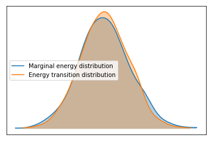

```python
#Sixth Attempt
pm.energyplot(trace);
```

The Gelman-Rubin statistics for all parameters are quite close to one, indicating convergence.

```python
# 2nd = 1.0088625860353992
max(np.max(score) for score in pm.gelman_rubin(trace).values())
```

```
1.0036887876149063
```

## Section 2 - Post Stratification Stage

We are now ready for the post-stratification step of MRP. First we combine with the Full Set of Constituency.

```python
profile_data_ps = uniq_profile_df_input_no_null[['Race_Factor_Cat','Age_Factor_Cat','Edu_Factor_Cat',
                               'Gender_Factor_Cat','Constituency_Init', 'ConstituencyP_Cat','Unnamed: 0',
                               'London Mayor','% Not Born in UK - 2011', 'Population - 2015',
                               '% with no qualifications - 2011', 'Remain_EnCode', 'WardName', 'Constituency', 'ConstituencyParty', 'Council_Party', '% Turnout', '% Majority']]
```

```python
#profile_data_ps.head(1)
profile_data_ps.shape
```

```
(604, 18)
```

```python
### Rename Mayor and Ward Features
profile_data_ps.rename(columns={ profile_data_ps.columns[6]: "Ward_Init" }, inplace = True)

profile_data_ps.rename(columns={ profile_data_ps.columns[7]: "London_Mayor" }, inplace = True)

profile_data_ps.rename(columns={ profile_data_ps.columns[9]: "Council_Poll" }, inplace = True)

### Rename State Level Predictors
profile_data_ps.rename(columns={ profile_data_ps.columns[8]: "Perc_Not_Born_UK" }, inplace = True)
profile_data_ps.rename(columns={ profile_data_ps.columns[10]: "Perc_No_Qual" }, inplace = True)

### Rename Mayor and Ward Features
profile_data_ps.rename(columns={profile_data_ps.columns[9]: "freq" }, inplace = True)

profile_data_ps.rename(columns={ profile_data_ps.columns[16]: "Perc_TurnOut" }, inplace = True)
profile_data_ps.rename(columns={ profile_data_ps.columns[17]: "Perc_Majority" }, inplace = True)
```

```python
#Fill in blanks otherwise Convert Cateogrical functon fails
profile_data_ps = profile_data_ps.fillna(0)

### Convert Categoricals into Numerical for Addtion Pre Model Load
profile_data_ps['Age_Factor_Cat'] = profile_data_ps['Age_Factor_Cat'].astype(np.int8)
profile_data_ps['Edu_Factor_Cat'] = profile_data_ps['Edu_Factor_Cat'].astype(np.int8)
```

```python
profile_data_ps.shape
```

```
(604, 18)
```

```python
ps_df = profile_data_ps
```

dataTypeSeries = ps_df.dtypes print(dataTypeSeries)

```python
ps_df.head(1)
#profile_data_ps.shape
```

|  | Race_Factor_Cat | Age_Factor_Cat | Edu_Factor_Cat | Gender_Factor_Cat | Constituency_Init | ConstituencyP_Cat | Ward_Init | London_Mayor | Perc_Not_Born_UK | freq | Perc_No_Qual | Remain_EnCode | WardName | Constituency | ConstituencyParty | Council_Party | Perc_TurnOut | Perc_Majority |
| --- | --- | --- | --- | --- | --- | --- | --- | --- | --- | --- | --- | --- | --- | --- | --- | --- | --- | --- |
| 0 | 2 | 0 | 1 | 0 | 0 | 1 | 0 | Sadiq Aman Khan - Labour Party | 57.3 | 14750.0 | 16.4 | 0 | Abbey | Barking | Labour | LAB | 58.1 | 35.5 |

We now set the values of the `theano.shared` variables in our PyMC3 model to the poststratification data and sample from the posterior predictive distribution.

```python
ps_gender_race = encode_gender_race(ps_df.Gender_Factor_Cat, ps_df.Race_Factor_Cat)
ps_age = ps_df.Age_Factor_Cat.values
ps_edu = ps_df.Edu_Factor_Cat.values
ps_age_edu = encode_age_edu(ps_df.Age_Factor_Cat, ps_df.Edu_Factor_Cat)
ps_region = ps_df.ConstituencyP_Cat.values
ps_state = ps_df.Constituency_Init.values
ps_n = ps_df.freq.values.astype(np.int64)
```

```python
np.unique(ps_state)
#ps_state[ps_state >= 550] = ps_state[ps_state >= 550] - (ps_state[ps_state >= 550] - 53)
```

```
array([ 0,  1,  2,  3,  4,  5,  6,  7,  8,  9, 10, 11, 12, 13, 14, 15, 16,
       17, 18, 19, 20, 21, 22, 23, 24, 25, 26, 27, 28, 29, 30, 31, 32, 33,
       34, 35, 36, 37, 38, 39, 40, 41, 42, 43, 44, 45, 46, 47, 48, 49, 50,
       51, 52, 53, 54, 55, 56, 57, 58, 59, 60, 61, 62, 63, 64, 65, 66, 67,
       68, 69], dtype=int8)
```

```python
gender_race_.set_value(ps_gender_race)
age_.set_value(ps_age)
edu_.set_value(ps_edu)
age_edu_.set_value(ps_age_edu)
poll_.set_value(np.zeros_like(ps_gender_race))
state_.set_value(ps_state)
use_poll_.set_value(0)
n_.set_value(ps_n)
```

```python
with model:
    pp_trace = pm.sample_ppc(trace, random_seed=SEED)
```

```python
PP_COLS = ['pp_yes_of_all_{}'.format(i) for i in range(pp_trace['obs'].shape[0])]

pp_df = pd.merge(ps_df,
                 pd.DataFrame(pp_trace['obs'].T, columns=PP_COLS),
                 left_index=True, right_index=True)
```

```python
pp_df.head(2)
```

|  | Race_Factor_Cat | Age_Factor_Cat | Edu_Factor_Cat | Gender_Factor_Cat | Constituency_Init | ConstituencyP_Cat | Ward_Init | London_Mayor | Perc_Not_Born_UK | freq | ... | pp_yes_of_all_990 | pp_yes_of_all_991 | pp_yes_of_all_992 | pp_yes_of_all_993 | pp_yes_of_all_994 | pp_yes_of_all_995 | pp_yes_of_all_996 | pp_yes_of_all_997 | pp_yes_of_all_998 | pp_yes_of_all_999 |
| --- | --- | --- | --- | --- | --- | --- | --- | --- | --- | --- | --- | --- | --- | --- | --- | --- | --- | --- | --- | --- | --- |
| 0 | 2 | 0 | 1 | 0 | 0 | 1 | 0 | Sadiq Aman Khan - Labour Party | 57.3 | 14750.0 | ... | 14750 | 14600 | 14649 | 13947 | 14387 | 14260 | 13980 | 14738 | 11481 | 13253 |
| 1 | 2 | 1 | 0 | 0 | 0 | 1 | 1 | Sadiq Aman Khan - Labour Party | 24.7 | 10600.0 | ... | 9669 | 7516 | 5934 | 3776 | 9723 | 8325 | 7727 | 10523 | 9088 | 6158 |

2 rows × 1018 columns

We complete the poststratification step by taking a weighted sum across the demographic cells within each state, to produce posterior predictive samples from the state-level opinion distribution.

```python
ps_prob = (pp_df.groupby('Constituency')
                .apply(lambda df: df[PP_COLS].sum(axis=0) / df.freq.sum()))
```

```python
ps_prob.head(2)
```

| Constituency | pp_yes_of_all_0 | pp_yes_of_all_1 | pp_yes_of_all_2 | pp_yes_of_all_3 | pp_yes_of_all_4 | pp_yes_of_all_5 | pp_yes_of_all_6 | pp_yes_of_all_7 | pp_yes_of_all_8 | pp_yes_of_all_9 | ... | pp_yes_of_all_990 | pp_yes_of_all_991 | pp_yes_of_all_992 | pp_yes_of_all_993 | pp_yes_of_all_994 | pp_yes_of_all_995 | pp_yes_of_all_996 | pp_yes_of_all_997 | pp_yes_of_all_998 | pp_yes_of_all_999 |
| --- | --- | --- | --- | --- | --- | --- | --- | --- | --- | --- | --- | --- | --- | --- | --- | --- | --- | --- | --- | --- | --- |
| Barking | 0.631256 | 0.808953 | 0.782706 | 0.039575 | 0.892177 | 0.720144 | 0.145700 | 0.901814 | 0.934005 | 0.059539 | ... | 0.733616 | 0.660489 | 0.442469 | 0.304390 | 0.679604 | 0.683253 | 0.562656 | 0.958266 | 0.639395 | 0.379676 |
| Battersea | 0.983743 | 0.999295 | 0.989987 | 0.661576 | 0.993756 | 0.976055 | 0.971466 | 0.999912 | 0.995315 | 0.982166 | ... | 0.984298 | 0.995887 | 0.998089 | 0.991722 | 0.980537 | 0.994531 | 0.992690 | 0.999736 | 0.998970 | 0.946570 |

2 rows × 1000 columns

The simplest summary of state-level opinion is the posterior expected mean, shown below.

```python
ps_mean = ps_prob.mean(axis=1)
```

```python
ps_mean.head(10)
```

```
Constituency
Barking                         0.607932
Battersea                       0.970493
Beckenham                       0.668174
Bermondsey and Old Southwark    0.967637
Bethnal Green and Bow                NaN
Bexleyheath and Crayford        0.337665
Brent Central                   0.787293
Brent North                     0.618387
Brentford and Isleworth         0.890580
Bromley and Chislehurst         0.681915
dtype: float64
```

```python
ps_mean.to_csv('ps_mean_1.csv')
profile_disagg_p.to_csv('profile_disagg_p_1.csv')
```

```python
profile_disagg_p, ps_mean_aligned = profile_disagg_p.align(ps_mean)
```

[figure not shown]

```python
fig, ax = plt.subplots(figsize=(8, 8))
ax.set_aspect('equal');

pct_formatter = FuncFormatter(lambda prop, _: '{:.1%}'.format(prop))

ax.plot([0.1, 0.7], [0.1, 0.7], '--', c='k', label="No change");
ax.scatter(profile_disagg_p, ps_mean_aligned);

ax.set_xlim(0.1, 0.7);
ax.xaxis.set_major_formatter(pct_formatter);
ax.set_xlabel("Disaggregation estimate");

ax.set_ylim(0.1, 0.7);
ax.yaxis.set_major_formatter(pct_formatter);
ax.set_ylabel("MRP estimate");

ax.legend(loc=2);
ax.set_title("Estimated EU Referendum Remain by Constituency");
```

Lets Compare our Estimations with subsequent work by Chris Hanretty using Martin Rosenbaum's BBC FOI Data

https://medium.com/@chrishanretty/ward-level-results-from-the-eu-referendum-b9df8dd29c98#.3cv6x3ura

https://en.wikipedia.org/wiki/Results_of_the_2016_United_Kingdom_European_Union_membership_referendum_by_constituency#cite_ref-medium.com/constituencyestimates_4-386

```python
eu_ref_data=pd.read_csv('data/EU-referendum-result-data-checked.csv')
```

```python
eu_ref_data.head(1)
```

|  | Constituency | MP | MP_Position | MP_Maj | Area | Remain | Leave |
| --- | --- | --- | --- | --- | --- | --- | --- |
| 0 | Barking | Margaret Hodge | Remain | 35.50% | Greater London | 0.4 | 0.6 |

```python
ps_mean_df = ps_mean.to_frame()
```

```python
ps_mean_df.head(1)
```

| Constituency | 0 |
| --- | --- |
| Barking | 0.607932 |

```python
results_join_df = pd.merge(eu_ref_data, ps_mean_df, on='Constituency', how='right')
results_join_df.rename(columns={ results_join_df.columns[7]: "Remain_Vote_Estimation" }, inplace = True)
results_join_df.rename(columns={ results_join_df.columns[6]: "Actual_Leave_Result" }, inplace = True)
results_join_df.rename(columns={ results_join_df.columns[5]: "Actual_Remain_Result" }, inplace = True)
results_join_df = results_join_df[['Constituency', 'Remain_Vote_Estimation', 'Actual_Remain_Result', 'Actual_Leave_Result']]
```

```python
results_join_df['Remain_Vote_Estimation'] = results_join_df['Remain_Vote_Estimation'].astype(float).map("{:.2%}".format)
results_join_df['Actual_Leave_Result'] = results_join_df['Actual_Leave_Result'].astype(float).map("{:.2%}".format)
results_join_df['Actual_Remain_Result'] = results_join_df['Actual_Remain_Result'].astype(float).map("{:.2%}".format)
```

## Analysis & Conclusion

```python
results_join_df.head(100)
```

|  | Constituency | Remain_Vote_Estimation | Actual_Remain_Result | Actual_Leave_Result |
| --- | --- | --- | --- | --- |
| 0 | Barking | 60.79% | 40.00% | 60.00% |
| 1 | Battersea | 97.05% | 77.00% | 23.00% |
| 2 | Beckenham | 66.82% | 52.00% | 48.00% |
| 3 | Bermondsey and Old Southwark | 96.76% | 73.00% | 27.00% |
| 4 | Bethnal Green and Bow | nan% | 69.00% | 31.00% |
| 5 | Bexleyheath and Crayford | 33.77% | 35.00% | 65.00% |
| 6 | Brent Central | 78.73% | 57.00% | 43.00% |
| 7 | Brent North | 61.84% | 57.00% | 43.00% |
| 8 | Brentford and Isleworth | 89.06% | 57.00% | 43.00% |
| 9 | Bromley and Chislehurst | 68.19% | 50.00% | 50.00% |
| 10 | Camberwell and Peckham | 91.74% | 70.00% | 30.00% |
| 11 | Carshalton and Wallington | 48.39% | 44.00% | 56.00% |
| 12 | Chelsea and Fulham | 96.71% | 71.00% | 29.00% |
| 13 | Chingford and Woodford Green | 35.97% | 51.00% | 49.00% |
| 14 | Chipping Barnet | 83.52% | 59.00% | 41.00% |
| 15 | Cities of London and Westminster | 89.57% | 71.00% | 29.00% |
| 16 | Croydon Central | 50.68% | 50.00% | 50.00% |
| 17 | Croydon North | 68.67% | 59.00% | 41.00% |
| 18 | Croydon South | 78.79% | 54.00% | 46.00% |
| 19 | Dagenham and Rainham | 37.25% | 30.00% | 70.00% |
| 20 | Dulwich and West Norwood | 97.52% | 78.00% | 22.00% |
| 21 | Ealing Central and Acton | 93.44% | 71.00% | 29.00% |
| 22 | Ealing North | 64.16% | 54.00% | 46.00% |
| 23 | East Ham | 79.57% | 53.00% | 47.00% |
| 24 | Edmonton | 71.44% | 55.00% | 46.00% |
| 25 | Eltham | 42.32% | 48.00% | 52.00% |
| 26 | Enfield North | 48.40% | 51.00% | 49.00% |
| 27 | Erith and Thamesmead | 43.27% | 46.00% | 54.00% |
| 28 | Feltham and Heston | 41.10% | 44.00% | 56.00% |
| 29 | Finchley and Golders Green | 88.27% | 69.00% | 31.00% |
| ... | ... | ... | ... | ... |
| 40 | Ilford North | 38.88% | 48.00% | 53.00% |
| 41 | Ilford South | 79.39% | 56.00% | 44.00% |
| 42 | Islington North | 98.90% | 78.00% | 22.00% |
| 43 | Islington South and Finsbury | 98.75% | 72.00% | 28.00% |
| 44 | Kensington | nan% | 69.00% | 31.00% |
| 45 | Kingston and Surbiton | 68.91% | 59.00% | 42.00% |
| 46 | Lewisham East | 72.17% | 65.00% | 35.00% |
| 47 | Lewisham West and Penge | 82.46% | 66.00% | 34.00% |
| 48 | Leyton and Wanstead | 92.59% | 63.00% | 37.00% |
| 49 | Mitcham and Morden | 56.29% | 55.00% | 45.00% |
| 50 | Old Bexley and Sidcup | 10.47% | 37.00% | 63.00% |
| 51 | Orpington | 27.60% | 43.00% | 58.00% |
| 52 | Poplar and Limehouse | nan% | 66.00% | 34.00% |
| 53 | Putney | 92.39% | 73.00% | 27.00% |
| 54 | Richmond Park | 91.39% | 73.00% | 28.00% |
| 55 | Romford | 16.39% | 31.00% | 69.00% |
| 56 | Ruislip, Northwood and Pinner | 72.67% | 51.00% | 49.00% |
| 57 | Sutton and Cheam | 55.78% | 49.00% | 51.00% |
| 58 | Tooting | 96.18% | 75.00% | 25.00% |
| 59 | Tottenham | 88.44% | 76.00% | 24.00% |
| 60 | Twickenham | 78.64% | 66.00% | 34.00% |
| 61 | Uxbridge and South Ruislip | 23.02% | 44.00% | 56.00% |
| 62 | Vauxhall | 99.26% | 78.00% | 22.00% |
| 63 | Walthamstow | 90.68% | 67.00% | 34.00% |
| 64 | West Ham | 84.73% | 53.00% | 47.00% |
| 65 | Westminster North | 90.28% | 67.00% | 33.00% |
| 66 | Wimbledon | 93.12% | 71.00% | 29.00% |
| 67 | Ealing, Southall | 76.00% | nan% | nan% |
| 68 | Enfield, Southgate | 82.38% | nan% | nan% |
| 69 | Lewisham, Deptford | 98.75% | nan% | nan% |

70 rows × 4 columns